# Готовим данные для анализа

- Я взял данные о домашках по математике, которые ученики МГ решали в течении года. Из выборки были исключены "подозрительные" ученики, которые были слишком похожи на кураторов. Так же в выборку не вошли те, у кого было менее 3 месяцев обучения в школе. Среднее количество просмотренных вебинаров в месяц у всех взятых учеников больше 8.

```python
import pandas as pd
import json
import numpy as np

df = pd.read_csv('all_downloads.csv')
sdf = df[df['subject'] == 'mat_ege']
sdf['Месяц'] = pd.to_datetime(sdf['Дата сдачи']).dt.month_name()

sdf = sdf.drop(sdf[sdf['Почта ученика'].str.split('@').str[1] == 'umschool.ru'].index)
grouped_sdf = sdf.groupby(['Почта ученика']).agg({'Баллы за ответ ученика':lambda x:('\n'.join(x)).split(),'Максимальное кол-во баллов за данную задачу':lambda x:('\n'.join(x)).split(),'ID номера':lambda x: ('\n'.join(x)).split(),'Месяц':lambda x: (' '.join(x)).split()})
grouped_sdf['month_nums'] = grouped_sdf['Месяц'].apply(lambda x: len(list(set(x))))
grouped_sdf['month_mean_web'] = grouped_sdf.apply(lambda x: len(x['Месяц'])/x['month_nums'], axis =1)
grouped_sdf = grouped_sdf.drop(grouped_sdf[(grouped_sdf['month_nums']<3) | (grouped_sdf['month_mean_web']<8)].index)
list_of_good_users = list(grouped_sdf.index)
sdf = sdf[sdf['Почта ученика'].apply(lambda x: x in list_of_good_users)]

num_df = sdf[['ID номера', 'Максимальное кол-во баллов за данную задачу']].drop_duplicates()
used_numbers = [num for item in num_df['ID номера'] for num in item.split('\n')[0:-1]]
max_points = [num for item in num_df['Максимальное кол-во баллов за данную задачу'] for num in item.split('\n')[0:-1]]
```

## Работа с базой заданий

- Из базы заданий извлекается информация о том, какие номера КИМ ученики решали. В выгрузке ДЗ есть лишь ID заданий, но при помощи базы мы можешь соединить задания и их номера в КИМ.

```python
mat_df = pd.read_csv('mat_basetasks.csv')
mat_df = mat_df[['ID', 'Класс в школе','Макс. балл', 'Номер в КИМ (порядок)']]
mat_df = mat_df.drop(mat_df[mat_df['Номер в КИМ (порядок)'] == 'Нет'].index)
mat_df = mat_df[mat_df['ID'].astype(str).apply(lambda x: x in used_numbers)]

number_kim_dict = dict(zip(mat_df['ID'].astype(str).to_list(), mat_df['Номер в КИМ (порядок)'].to_list()))
grouped_sdf['kims'] = grouped_sdf.apply(lambda x: [number_kim_dict.get(num,'0') for num in x['ID номера']], axis = 1)

kim_nums = [str(num) for num in np.arange(1,19)]
def count_kim(x, kim_nums):
    nums = []

    for num in kim_nums:
        nums.append(len([item for item in x if item == num]))
    return nums

grouped_sdf['nums'] = grouped_sdf['kims'].apply(lambda x: count_kim(x,kim_nums))
grouped_sdf = grouped_sdf.reset_index()
```

### Вытаскиваем данные пробников

- Результаты пробников служат для нас "таргетом". Мы берём результаты лишь последних пробников, которые ученики решали в период с начала февраля по сегодняшний день. Это даёт нам право говорить, что эти результаты получены по итогам работы над собой и обучения в школе, а не какой-то рандомный результат.

```python
mat_prob = pd.read_csv('mat_probniks.csv')[['Почта ученика','Дата сдачи','Результаты']]
mat_prob = mat_prob.drop_duplicates(subset = ['Почта ученика'], keep = 'last')
mat_prob = mat_prob[pd.to_datetime(mat_prob['Дата сдачи'])>pd.to_datetime('2022-02-01')]
list_of_mails_with_probs = mat_prob['Почта ученика'].to_list()
user_result_dict = dict(zip(mat_prob['Почта ученика'].to_list(), mat_prob['Результаты'].to_list()))
grouped_sdf = grouped_sdf[grouped_sdf['Почта ученика'].apply(lambda x: x in list_of_mails_with_probs)]
grouped_sdf['result'] = grouped_sdf['Почта ученика'].apply(lambda x: user_result_dict.get(x))
mdf = pd.DataFrame(grouped_sdf['nums'].tolist(), index = grouped_sdf.index)
mdf['result'] = grouped_sdf['result']
mdf = mdf.set_axis([str(i) for i in range(1,19)]+['result'], axis=1, inplace=False)
```

```python
mdf.to_csv('data_set_to_nn.csv')
```

## Итоги подготовки данных

- В качестве входных данных для наших расчётных моделей будет пара: количество номеров КИМ - результат последнего пробника.
- Количество номеров КИМ - это количество заданий определённого номера КИМ, который ученик решил за время подготовки. На вход расчётной модели подается вектор-массив, в котором каждый элемент соответствует определённому номеру в КИМ.

### Особенности моделей

- Нейросеть выбранная для данной задачи - это самый простой регрессор. Он позволяет понять "принципиальную предсказательную возможность". Более сложные модели могут улучшить результат, но не изменить принципиальной картины
- Помимо нейросети была выбрана модель деревьев решений. Это классическая модель машинного обучения позволяет наглядно представить то, как формируется решение у машины. Иногда, если результаты нейросети и дерева решений схожи - удобно смотреть на то, как выглядит дерево решений, чтобы интерпретировать результаты
- Результатом для всех сетей является R^2 score. Лучше всего - это 1, хуже всего -1.

### Модель нейросети

```python
from sklearn.neural_network import MLPRegressor
from sklearn.datasets import make_regression
from sklearn.model_selection import train_test_split
X, y = mdf.iloc[:,0:-1].to_numpy(), mdf.iloc[:,-1].to_numpy()
X_train, X_test, y_train, y_test = train_test_split(X, y,random_state=1)
regr = MLPRegressor(random_state=1, max_iter=500).fit(X_train, y_train)
```

```python
regr.score(X_test, y_test)
```

```
-0.01644489896247081
```

### Модель деревьев решений

```python
from sklearn import tree
from sklearn.model_selection import train_test_split
X, y = mdf.iloc[:,0:-1].to_numpy(), mdf.iloc[:,-1].to_numpy()
X_train, X_test, y_train, y_test = train_test_split(X, y,random_state=1)
clf = tree.DecisionTreeRegressor()
clf = clf.fit(X_train, y_train)
clf.score(X_test,y_test)
```

```
-0.8143959034661008
```

### Карта корреляций

- Парные корреляции хорошо показывают, как одна величина "взимосвязана" с другой. В нашем случае, если пара свойств имеют высокий коэффициент корреляции, это значит, что они часто идут вместе. То есть часто какое-то одно задание решается так же часто, как и другое

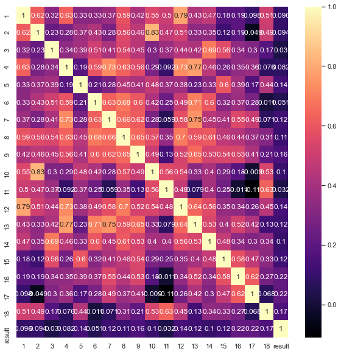

```python
import matplotlib.pyplot as plt
import seaborn as sns

sns.set(rc = {'figure.figsize':(10,10)})
cm = np.corrcoef(mdf.values.T)
sns.heatmap(cm,annot=True, cmap='magma', xticklabels=mdf.columns.values, yticklabels=mdf.columns.values)
```

### Выбрасываем тех, у кого result < 10

```python
mdf_u = mdf[mdf['result']>10]
```

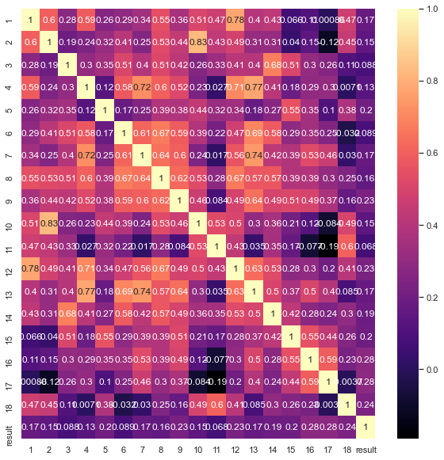

```python
sns.set(rc = {'figure.figsize':(10,10)})
cm = np.corrcoef(mdf_u.values.T)
sns.heatmap(cm,annot=True, cmap='magma', xticklabels=mdf.columns.values, yticklabels=mdf.columns.values)
```

### Формируем новую input-матрицу

```python
kim_nums = [str(num) for num in np.arange(1,19)]

def res_per(x, kim_nums):

    persentage = []
    for num in kim_nums:
        ball = np.array([int(item) for item in x['Баллы за ответ ученика']])
        max_point = np.array([int(item) for item in x['Максимальное кол-во баллов за данную задачу']])
        kim = np.array(x['kims'])
        nums = np.array(x['nums'])

        index1 =np.where(kim == num)[0]

        index2 =np.where(max_point != 0)[0]
        index = np.intersect1d(index1, index2)

        if len(index) != 0:

            per = sum(ball[index]/max_point[index])/len(index)

            persentage.append(sum(ball[index]/max_point[index])/len(index))

        else:
            persentage.append(0)

    return persentage

grouped_sdf['persentage'] = grouped_sdf.apply(lambda x: res_per(x,kim_nums), axis = 1)

mdf_p = pd.DataFrame(grouped_sdf['persentage'].tolist(), index = grouped_sdf.index)
mdf_p['result'] = grouped_sdf['result']
mdf_p = mdf_p.set_axis([str(i) for i in range(1,19)]+['result'], axis=1, inplace=False)
```

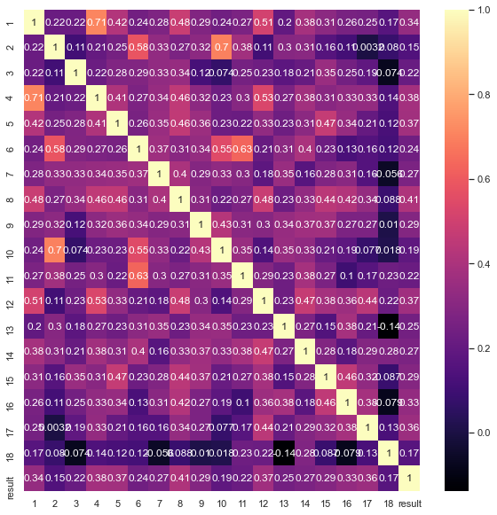

```python
#cm = np.corrcoef(mdf_p.values.T)
cm = mdf_p.corr()
sns.heatmap(cm,annot=True, cmap='magma', xticklabels=mdf_p.columns.values, yticklabels=mdf_p.columns.values)
```

## Построение нейросети. Разный способ нормализации данных

### Нормализация по гауссу

```python
from sklearn.neural_network import MLPRegressor
from sklearn.datasets import make_regression
from sklearn.model_selection import train_test_split

from sklearn.preprocessing import StandardScaler

std_scaler = StandardScaler()
mdf_std = pd.DataFrame(std_scaler.fit_transform(mdf_p), columns=mdf_p.columns)

X, y = mdf_std.iloc[:,0:-1].to_numpy(), mdf_std.iloc[:,-1].to_numpy()
X_train, X_test, y_train, y_test = train_test_split(X, y,random_state=1)
regr = MLPRegressor(random_state=1, max_iter=500).fit(X_train, y_train)

regr.score(X_test, y_test)
```

```
-0.11477671505125109
```

### Нормализация по модулю

```python
from sklearn.neural_network import MLPRegressor
from sklearn.datasets import make_regression
from sklearn.model_selection import train_test_split
from sklearn.preprocessing import MaxAbsScaler


scaler = MaxAbsScaler()
mdf_scl = pd.DataFrame(scaler.fit_transform(mdf_p), columns=mdf_p.columns)

X, y = mdf_scl.iloc[:,0:-1].to_numpy(), mdf_scl.iloc[:,-1].to_numpy()
X_train, X_test, y_train, y_test = train_test_split(X, y,random_state=1)
regr = MLPRegressor(random_state=1, max_iter=500).fit(X_train, y_train)

regr.score(X_test, y_test)
```

```
0.20181574627852783
```

## Дерево решений. Разные способы нормализации данных

### Нормализация по гауссу

```python
from sklearn.neural_network import MLPRegressor
from sklearn.datasets import make_regression
from sklearn.model_selection import train_test_split

from sklearn.preprocessing import StandardScaler

std_scaler = StandardScaler()
mdf_std = pd.DataFrame(std_scaler.fit_transform(mdf_p), columns=mdf_p.columns)

X, y = mdf_std.iloc[:,0:-1].to_numpy(), mdf_std.iloc[:,-1].to_numpy()
X_train, X_test, y_train, y_test = train_test_split(X, y,random_state=1)
clf = tree.DecisionTreeRegressor()
clf = clf.fit(X_train, y_train)
clf.score(X_test,y_test)
```

```
-0.5853441323441215
```

### Нормализация по модулю

```python
from sklearn.neural_network import MLPRegressor
from sklearn.datasets import make_regression
from sklearn.model_selection import train_test_split

from sklearn.preprocessing import StandardScaler

scaler = MaxAbsScaler()
mdf_scl = pd.DataFrame(scaler.fit_transform(mdf_p), columns=mdf_p.columns)

X, y = mdf_scl.iloc[:,0:-1].to_numpy(), mdf_scl.iloc[:,-1].to_numpy()
X_train, X_test, y_train, y_test = train_test_split(X, y,random_state=1)
clf = tree.DecisionTreeRegressor()
clf = clf.fit(X_train, y_train)
clf.score(X_test,y_test)
```

```
-0.5611004179036976
```

## Пробуем классификацию

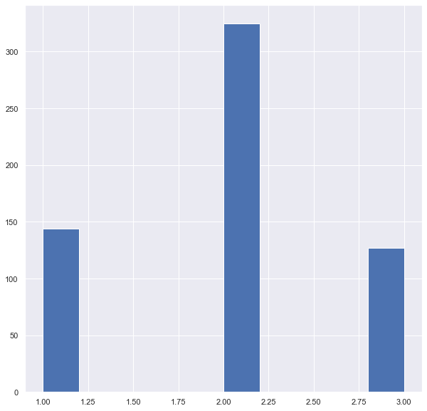

```python
def result_class(x):

    n3 = 75
    n2 = 40

    if x >=n3:
        return 3
    elif x<n3 and x>=n2:
        return 2
    elif x<n2:
        return 1
    else:
        return 0
mdf['class'] = mdf['result'].map(result_class)

X = mdf.iloc[:,0:18].values
Y = mdf.iloc[:,19].values
mdf['class'].hist()
```

```python
from sklearn.model_selection import train_test_split
import pandas as pd

from sklearn.neural_network import MLPClassifier
from sklearn.neighbors import KNeighborsClassifier
from sklearn.svm import SVC
from sklearn.gaussian_process import GaussianProcessClassifier
from sklearn.ensemble import GradientBoostingClassifier
from sklearn.gaussian_process.kernels import RBF
from sklearn.tree import DecisionTreeClassifier
from sklearn.ensemble import ExtraTreesClassifier
from sklearn.ensemble import RandomForestClassifier, AdaBoostClassifier
from sklearn.naive_bayes import GaussianNB
from sklearn.discriminant_analysis import QuadraticDiscriminantAnalysis
from sklearn.linear_model import SGDClassifier

X_train, X_test, Y_train, Y_test = train_test_split(X, Y, test_size=0.2)
```

```python
names = ["Nearest_Neighbors", "Linear_SVM", "Polynomial_SVM", "RBF_SVM", "Gaussian_Process",
         "Gradient_Boosting", "Decision_Tree", "Extra_Trees", "Random_Forest", "Neural_Net", "AdaBoost",
         "Naive_Bayes", "QDA", "SGD"]

classifiers = [
    KNeighborsClassifier(3),
    SVC(kernel="linear", C=0.025),
    SVC(kernel="poly", degree=3, C=0.025),
    SVC(kernel="rbf", C=1, gamma=2),
    GaussianProcessClassifier(1.0 * RBF(1.0)),
    GradientBoostingClassifier(n_estimators=100, learning_rate=1.0),
    DecisionTreeClassifier(max_depth=5),
    ExtraTreesClassifier(n_estimators=10, min_samples_split=2),
    RandomForestClassifier(max_depth=5, n_estimators=100),
    MLPClassifier(alpha=1, max_iter=1000),
    AdaBoostClassifier(n_estimators=100),
    GaussianNB(),
    QuadraticDiscriminantAnalysis(),
    SGDClassifier(loss="hinge", penalty="l2")]
```

```python
scores = []
for name, clf in zip(names, classifiers):
    clf.fit(X_train, Y_train)
    score = clf.score(X_test, Y_test)
    scores.append(score)
```

```python
scores
```

```
[0.45,
 0.5333333333333333,
 0.5166666666666667,
 0.5166666666666667,
 0.5083333333333333,
 0.5166666666666667,
 0.4583333333333333,
 0.525,
 0.5083333333333333,
 0.475,
 0.44166666666666665,
 0.4166666666666667,
 0.48333333333333334,
 0.4166666666666667]
```

### Классификация на основе процента решённых задач

```python
def result_class(x):

    n3 = 75
    n2 = 40

    if x >=n3:
        return 3
    elif x<n3 and x>=n2:
        return 2
    elif x<n2:
        return 1
    else:
        return 0
mdf_p['class'] = mdf['result'].map(result_class)

X = mdf_p.iloc[:,0:18].values
Y = mdf_p.iloc[:,19].values
```

```python
X_train, X_test, Y_train, Y_test = train_test_split(X, Y, test_size=0.2)
scores = []
for name, clf in zip(names, classifiers):
    clf.fit(X_train, Y_train)
    score = clf.score(X_test, Y_test)
    scores.append(score)
```

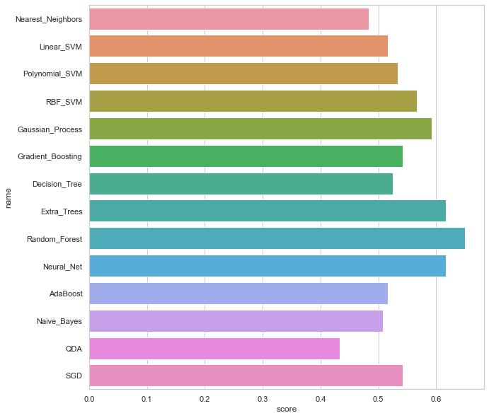

```python
df = pd.DataFrame()
df['name'] = names
df['score'] = scores
sns.set(style="whitegrid")
ax = sns.barplot(y="name", x="score", data=df)
```

### Поиск оптимального деления по баллам

```python
def result_class(x, n3, n2):

    if x >=n3:
        return 3
    elif x<n3 and x>=n2:
        return 2
    elif x<n2:
        return 1
    else:
        return 0

scores = []
n3_res = []
n2_res = []

n3_list= np.arange(60,95, 5)
n2_lsit = np.arange(40,75, 5)

for n3 in n3_list:
    for n2 in n2_lsit:

        if n3>n2:

            mdf_p['class'] = mdf['result'].apply(lambda x: result_class(x,n3,n2))

            X = mdf_p.iloc[:,0:18].values
            Y = mdf_p.iloc[:,19].values


            X_train, X_test, Y_train, Y_test = train_test_split(X, Y, test_size=0.2)
            clf =     RandomForestClassifier(max_depth=5, n_estimators=100)
            clf.fit(X_train, Y_train)
            score = clf.score(X_test, Y_test)

            scores.append(score)
            n3_res.append(n3)
            n2_res.append(n2)
```

```python
res_df = pd.DataFrame({'score':scores,'n2':n2_res,'n3':n3_res})
```

```python
# res_df.query("n2>20 and n3==85")
res_df[res_df['score'] == res_df['score'].max()]
```

|  | score | n2 | n3 |
| --- | --- | --- | --- |
| 37 | 0.791667 | 45 | 90 |

```python
mdf_p['class'] = mdf['result'].apply(lambda x: result_class(x,85,40))

X = mdf_p.iloc[:,0:18].values
Y = mdf_p.iloc[:,19].values


X_train, X_test, Y_train, Y_test = train_test_split(X, Y, test_size=0.2)
clf =     RandomForestClassifier(max_depth=5, n_estimators=100)
clf.fit(X_train, Y_train)
score = clf.score(X_test, Y_test)


score
```

```
0.8
```

```python
X_random = np.random.random(18)
X_random
```

```
array([0.84847056, 0.21580963, 0.0812803 , 0.94620488, 0.84601379,
       0.65745884, 0.6937793 , 0.23157516, 0.96797912, 0.07426555,
       0.61765869, 0.37744196, 0.54516534, 0.12607059, 0.89246789,
       0.15282913, 0.81955655, 0.87827652])
```

```python
clf.predict(X_random.reshape(1,-1))
```

```
array([2], dtype=int64)
```

```
Задание 1, Важность: 0.05833
Задание 2, Важность: 0.03296
Задание 3, Важность: 0.04936
Задание 4, Важность: 0.10737
Задание 5, Важность: 0.11102
Задание 6, Важность: 0.04185
Задание 7, Важность: 0.03661
Задание 8, Важность: 0.07912
Задание 9, Важность: 0.06832
Задание 10, Важность: 0.02657
Задание 11, Важность: 0.04291
Задание 12, Важность: 0.06217
Задание 13, Важность: 0.02238
Задание 14, Важность: 0.05038
Задание 15, Важность: 0.05201
Задание 16, Важность: 0.05134
Задание 17, Важность: 0.07868
Задание 18, Важность: 0.02862
```

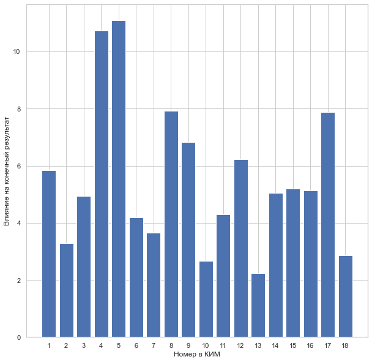

```python
from matplotlib import pyplot


importance = clf.feature_importances_
# summarize feature importance
for i,v in enumerate(importance):
	print('Задание %0d, Важность: %.5f' % (i+1,v))
# plot feature importance
pyplot.bar([x+1 for x in range(len(importance))], importance*100)
pyplot.xticks(np.arange(1,19))
pyplot.xlabel('Номер в КИМ')
pyplot.ylabel('Влияние на конечный результат')
pyplot.show()
```

### Попробуем потюнить модель

- в самой модели можно изменить некоторые входные параметры, и это иногда позволяет улучшить предсказания

```python
from sklearn.model_selection import GridSearchCV
import numpy as np

max_features_range = np.arange(1,6,1)
n_estimators_range = np.arange(10,210,10)
param_grid = dict(max_features=max_features_range, n_estimators=n_estimators_range)

rf = RandomForestClassifier()

grid = GridSearchCV(estimator=rf, param_grid=param_grid, cv=5)
```

```python
mdf_p['class'] = mdf['result'].apply(lambda x: result_class(x,85,40))

X = mdf_p.iloc[:,0:18].values
Y = mdf_p.iloc[:,19].values


X_train, X_test, Y_train, Y_test = train_test_split(X, Y, test_size=0.2)

grid.fit(X_train, Y_train)
print("The best parameters are %s with a score of %0.2f"
      % (grid.best_params_, grid.best_score_))
```

```
The best parameters are {'max_features': 3, 'n_estimators': 160} with a score of 0.77
```

### Попробуем визуализировать результат

```python
grid_results = pd.concat([pd.DataFrame(grid.cv_results_["params"]),pd.DataFrame(grid.cv_results_["mean_test_score"], columns=["Accuracy"])],axis=1)
grid_results.head()

grid_contour = grid_results.groupby(['max_features','n_estimators']).mean()

grid_reset = grid_contour.reset_index()
grid_reset.columns = ['max_features', 'n_estimators', 'Accuracy']
grid_pivot = grid_reset.pivot('max_features', 'n_estimators')

x = grid_pivot.columns.levels[1].values
y = grid_pivot.index.values
z = grid_pivot.values
```

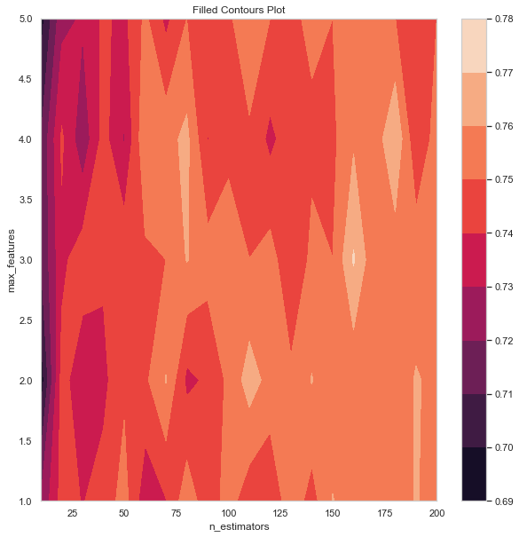

```python
import matplotlib.pyplot as plt


X_contour, Y_contour = np.meshgrid(x, y)
Z_contour = z
fig,ax=plt.subplots(1,1)
cp = ax.contourf(X_contour, Y_contour, Z_contour)
fig.colorbar(cp) # Add a colorbar to a plot
ax.set_title('Filled Contours Plot')
ax.set_xlabel('n_estimators')
ax.set_ylabel('max_features')
plt.show()
```

# Выводы которые можно сделать сейчас

- Количество решенных задач не является надёжным маркером для модели предсказания конечного балла. В разделении на категории (кластеризации) - эти данные показывают себя лучше
- В задаче о предсказании баллов, "качество" решённых задач показывает себя чуточку лучше, чес количество. Однако тоже не достаточно, чтобы делать какие-то надёжные предсказания в числах
- При попытке разделить учеников на 3 категории, по количеству набранных баллов, данные о "качестве" решённых задач при определенных параметрах может давать 80% аккуратности предсказаний
- Результаты продолжают сильно зависеть от способа "разбиения" данных на обучающую часть и на тренировочную. Это говорит не о слишком релевантной выборке. С увеличением количества данных - проблема должна решиться